# Multiple Linear Regression

MATH 325 - Brother Saunders

Andrew Seaman

02-17-2026

## Introduction

### Background

**Data Collection with Apple Devices**

The iPhone [^1] (*June 29, 2007*) in tandem with the Apple Watch [^2](*April 24,2015*) record numerous health metrics for the user/wearer made accessible in the IOS Health App [^3] (*September 17, 2014*). Per Apple’s promotions, users are intended to use these metrics to set goals and train more effectively. Two intriguing metric to avid and casual health conscious users alike is daily total step count and average heart rate. Measurements are more accurate for individuals who use an Apple Watch because wearable devices tend to be on the user’s person more consistently than an iPhone especially during exercise when a lot of valuable data is collected. In particular, Heart Rate can’t be recorded with an iPhone alone.

**Device Use History**

The subject of this study, who is also the author, first began collecting health metrics in the late 2010s. Below is a timeline of device acquisition and subsequent use:

1. Sep 2017 - iPhone SE [^4]
2. Jun 2019 - iPhone 7 [^5]
3. Oct 2022 - iPhone 12 Pro [^6]
4. Jul 2024 - Apple Watch 1 [^7]
5. Jan 2025 - iPhone 16 Pro Max [^8]
6. Feb 2025 - Apple Watch 10 [^9]

### Setup

First, several code libraries were used to perform the statistical tests.

**Libraries**

These **libraries** are used to reproduce this analysis.

```r
# > Libraries
library(tidyverse)
library(mosaic)
library(car)
library(pander)
library(readr)          # > Used to import the data
library(scales)         # > Needed? ChatGPT gave it to me when helping me write the big plotting function (jitter-box-line-plot 1 and 2)
library(directlabels)
#library(lubridate)     # > For date extraction in the 2nd plot of the Graphics section
```

Next, the author’s health data was imported and cleaned to improve readability.

**Data**

This **data** is imported locally and the date field data type is set to a date type.

```r
# > DATA IMPORT
#   ——————————————————————————————————————————————————————————

# > Source 1: limited dataset
# file_path <- "../../Data/iosHealth/health_export_2026-01-12.csv"
# health <- read_csv(file_path, col_types = cols(Date = col_date(format = "%m/%d/%y")))

# Source 2: expanded dataset
health <- read_csv("../../Data/iosHealth/IOS_health_2017-2026.csv",
    col_types = cols(Date = col_date(format = "%m/%d/%y")))
#  [1] "Date"
#  [2] "Cycling Distance (sum)"
#  [3] "Exercise Minutes (sum)"
#  [4] "Lean Body Mass (most recent)"
#  [5] "Walking/Running Distance (sum)"
#  [6] "Walking HR Avg (average)"
#  [7] "Mindful Minutes (sum)"
#  [8] "Body Temperature (Average) (average)"
#  [9] "Basal Energy (sum)"
# [10] "Blood Glucose (Most Recent) (most recent)"
# [11] "Heart Rate (average)"
# [12] "Flights Climbed (sum)"
# [13] "Headphone Audio (average)"
# [14] "Respiratory Rate (average)"
# [15] "Body Fat % (most recent)"
# [16] "Environmental Audio (average)"
# [17] "Swimming Distance (sum)"
# [18] "Blood Oxygen (average)"
# [19] "Body Temperature (Most Recent) (most recent)"
# [20] "Sleep (sum)"
# [21] "BP Diastolic (Average) (average)"
# [22] "VO2 Max (most recent)"
# [23] "BP Systolic (Most Recent) (most recent)"
# [24] "BP Systolic (Average) (average)"
# [25] "Blood Glucose (Average) (average)"
# [26] "Sleep (Core) (sum)"
# [27] "Total Energy (sum)"
# [28] "HRV (SDNN) (average)"
# [29] "BP Diastolic (Most Recent) (most recent)"
# [30] "Steps (sum)"
# [31] "Weight (Most Recent) (most recent)"
# [32] "Resting Heart Rate (average)"
# [33] "Sleep (REM) (sum)"
# [34] "Sleep (Asleep) (sum)"
# [35] "Sleep (Deep) (sum)"
```

Lastly, the original **column names** were cleaned up.

```r
# > DATA CLEANING 1
#   ——————————————————————————————————————————————————————————

# 1) Rename fields; select columns; filter by year
health <- health %>%
  rename(
    HeartRate = `Heart Rate (average)`,
    Steps = `Steps (sum)`
  ) %>%
  select(Date, HeartRate, Steps) %>%
# > Only use data from 2023-2026
  filter(year(Date) >= 2023)



# 2) Add columns
health <- health %>%
  mutate(
    Year = year(Date),                   # > Normal column: Extract year value from `Date` column.
    is_2023 = ifelse(Year == 2023, 1, 0) # > Dummy column: subset the data to isolate 2023
)
```

## Analysis

#### Hypothesis

This analysis models daily **total steps** as a function of an individual’s daily **average heart rate**. Because patterns observed in 2023 appeared to differ from subsequent years, the data are partitioned using a binary indicator that distinguishes observations from 2023 from those occurring in 2024–2026. The regression model includes both this indicator and its interaction with heart rate, allowing the baseline level of steps and the heart rate–steps relationship in 2023 to differ from the pooled post-2023 period.

$$\underbrace{Y_i}_\text{Total Steps} \underbrace{=}_{\sim}
\overbrace{\beta_0}^{\stackrel{\text{y-int}}{\text{baseline}}} +
\overbrace{\beta_1}^{\stackrel{\text{slope}}{\text{baseline}}}
\underbrace{X_{1i}}_\text{Avg Heart Rate} +
\overbrace{\beta_2}^{\stackrel{\text{change
in}}{\text{y-int}}} \underbrace{X_{2i}}_\text{1 if 2023} +
\overbrace{\beta_3}^{\stackrel{\text{change in}}{\text{slope}}}
\underbrace{X_{1i}X_{2i}}_\text{Interaction} + \epsilon_i$$

$$H_0: \beta_2 = 0 \text{ (Equal baseline daily steps for 2023 and
2024–2026)}\\
H_a: \beta_2 \neq 0 \text{ (Different baseline daily steps in 2023
compared to 2024–2026)}\\
\alpha = 0.05$$

We’re testing whether the relationship between heart rate and steps differs between 2023 and the pooled post-2023 period. We’ll use $\alpha = 0.05$.

$$H_0:\ \beta_3 = 0 \quad \text{(Same heart rate:steps relationship in
2023 and 2024–2026)}\\
H_a:\ \beta_3 \neq 0 \quad \text{(Different heart rate:steps
relationship in 2023)}$$

#### Graphics

First, we’ll plot each variable independently and look at the density of the data year-over-year (YoY) before comparing the variables against each other looking for covariance where one variable affects the other while accounting for time in years.

```r
# 1) Function: df of means by Year
#    ————————————————————————————————————————————————————————
df_means <- function(df, var) {
  df %>%
    filter(!is.na({{ var }}), !is.na(Year)) %>%
    group_by(Year) %>%
    summarize(mean = mean({{ var }}, na.rm = TRUE), .groups = "drop")
}



# 2) Function: counts of non-missing points by Year
#    ————————————————————————————————————————————————————————
df_counts <- function(df, var) {
  df %>%
    filter(!is.na({{ var }}), !is.na(Year)) %>%
    count(Year, name = "Points")
}



# 3) Function: Jitter Box Line Plot
#    ————————————————————————————————————————————————————————

# > Function start and parameters       ylimits: optional parameter
jitter_box_line_plot <- function(df, var, title, subtitle, ylab, xlab) {
  # > Clean dataframe
    df_clean <- df %>%
        filter(!is.na({{ var }}), !is.na(Year))
  # > Order years
    year_levels <- sort(unique(df_clean$Year))


  # > Base plot
    ggplot(df_clean, aes(x = factor(Year), y = {{ var }}, color = factor(Year))) +
  #   > Boxplot
      geom_boxplot(outlier.alpha = 0) +
  #   > Jitter plot
      geom_jitter(alpha = 0.2, width = 0.2) +
  #   > Line of means
      geom_line(
        data = df_means(df, {{ var }}),
        aes(x = factor(Year), y = mean, group = 1),
        inherit.aes = FALSE
      ) +
  #   > Specify upper y-axis max limit
      # scale_y_continuous(limits = {{ylimits}})+
  #   > Counts
      geom_label(
        data = df_counts(df, {{ var }}),
        aes(x = factor(Year), y = Inf, label = Points),
        vjust = 1.5,
        show.legend = FALSE,
        inherit.aes = FALSE
      ) +
  #   > Label for counts
      annotate(
        "text",
        x = as.character(min(year_levels)),  # leftmost year (factor-safe)
        y = Inf,
        label = "Points:",
        vjust = 2.2,
        hjust = 1.5
      ) +
  #   > Labels
      labs(title = title, subtitle = subtitle, y = ylab, x = xlab) +
  #   > Color scale
      scale_color_brewer(palette = "Set1", name = "Year") +
  #   > Base theme
      theme_bw() +
  #   > Custom theme
      theme(
        legend.position = "none",
        plot.margin = margin(10, 30, 10, 10)
      ) +
  #   > ??
      coord_cartesian(clip = "off")
  }
```

Variable: **`Heart Rate`**

In the plot below, 2026 shows three things of note:

1. High right skew or greater spread in the upper 50% of the data about twice that of other years.
2. The median is higher than for others years.
3. The mean is much further away (above) from the median than for other years.

Additionally, because the subject had sporadic access to heart rate measuring devices until mid-2024 data collection is scarce in 2023.

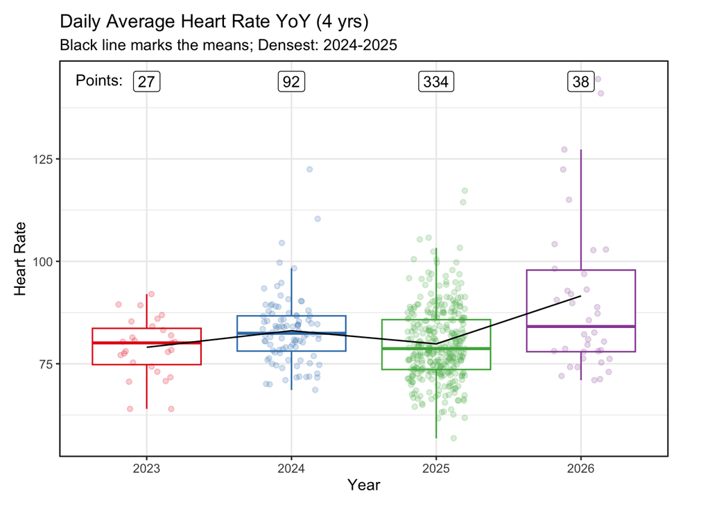

```r
jitter_box_line_plot(
  health,
  HeartRate,
  "Daily Average Heart Rate YoY (4 yrs)",
  "Black line marks the means; Densest: 2024-2025",
  "Heart Rate",
  "Year"
)
```

Variable: **`Steps`**

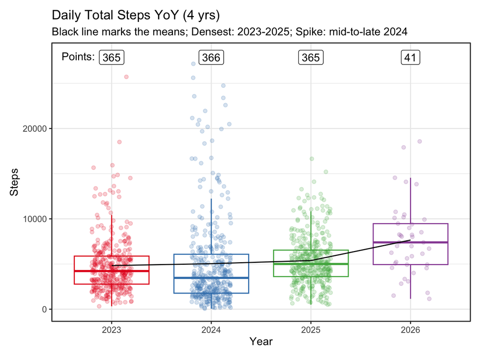

```r
jitter_box_line_plot(
  health,
  Steps,
  # c(0,30000),
  "Daily Total Steps YoY (4 yrs)",
  "Black line marks the means; Densest: 2023-2025; Spike: mid-to-late 2024",
  "Steps",
  "Year"
)
```

```r
# > ATTEMPT 3.1 - HELPER
# > (status: working)
# ———————————————————————————————————————————————————————————

# 1) A clean df where both variables have value in the same row
df_finite <- health %>%
  filter(is.finite(HeartRate), is.finite(Steps), !is.na(Year))


# 2) A df of just 2023
df_2023 <- df_finite %>%
  filter(Year == 2023)   # (or is_2023 == 1 if that column exists)


# 3) A df excluding 2023
df_not_2023 <- df_finite %>%
  filter(Year != 2023)
```

The plots above hint at a time trend in the data and the plots below generally show a positive trend between avg heart rate and total steps for all years except **2023** which shows a downard or negative correlation between the variables.

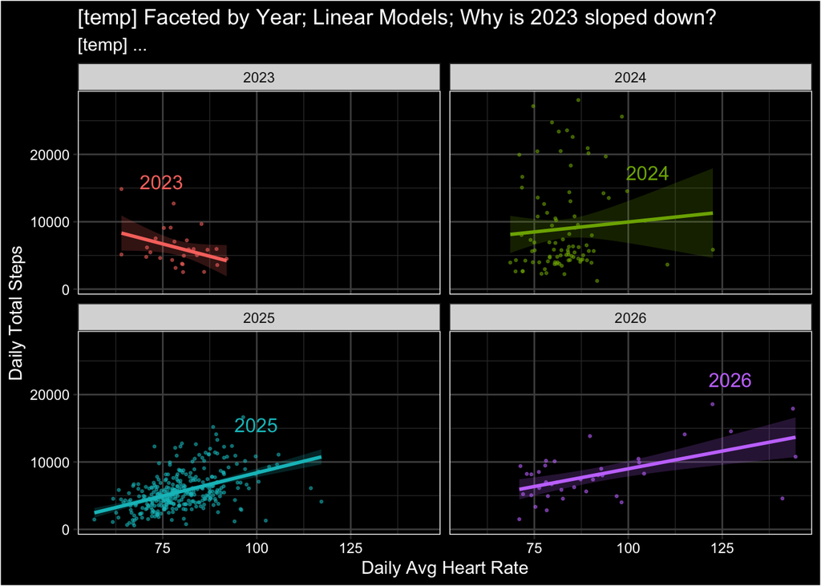

```r
# > ATTEMPT 3.2 - PLOT
# > (status: working)
#
# > Changes:
#   - [x] Remove red and green mean and median lines
#   - [x] Facet by year
# ———————————————————————————————————————————————————————————

# > Plot: Scatterplot + Smooth LM: Comparing both variables `Heart Rate` and `Steps`
ggplot(df_finite, aes(x = HeartRate, y = Steps, color = as.factor(Year), fill = as.factor(Year))) +
  # geom_point(data = df_2023, color = "#F8766D", pch = 19, size = 0.5) +
  geom_point(pch = 19, size = 0.5, alpha = .5) +
  theme_bw() +
  theme(
    panel.background = element_rect(fill = "black"),
    plot.background  = element_rect(fill = "black"),
    panel.border     = element_rect(color = "white"),
    text = element_text(color = "white"),
    axis.text = element_text(color = "white"),
    axis.title = element_text(color = "white"),
    panel.grid.major = element_line(color = "grey30"),
    panel.grid.minor = element_line(color = "grey20"),
    legend.position = "none"
  ) +
  labs(
    title = "[temp] Faceted by Year; Linear Models; Why is 2023 sloped down?",
    subtitle = "[temp] ...",
    x = "Daily Avg Heart Rate",
    y = "Daily Total Steps"
  ) +
  geom_smooth(method = "lm", se = TRUE, alpha = .2) +
  facet_wrap(~Year)+ # Optionally add: `, scales = "free"`
  geom_dl(label = df_finite$Year,
          method = list(
            "last.points",
            hjust = 2,
            vjust = -5
          )
  )
```

Next, we’ll isolate the data for 2023 and pool the other years together to draw a comparison of downward (negative correlation) *versus* upward (positive correlation) lines.

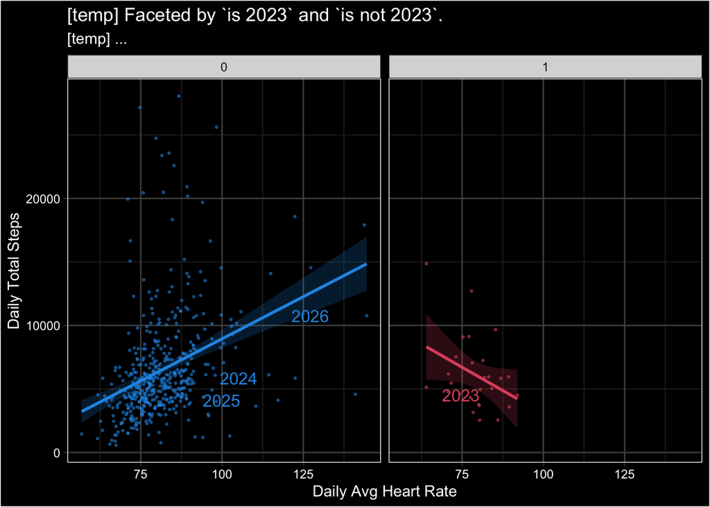

```r
# > Plot: 2023 vs. all other years (downward lines vs. upward lines)
ggplot(df_finite, aes(x = HeartRate, y = Steps, color = as.factor(is_2023), fill = as.factor(is_2023))) +
  # geom_point(data = df_2023, color = "#F8766D", pch = 19, size = 0.5) +
  geom_point(pch = 19, size = 0.5, alpha = .5) +
  geom_dl(
    label = df_finite$Year,
    method = list("last.points", hjust = 2)
  )+
  theme_bw() +
  theme(
    panel.background = element_rect(fill = "black"),
    plot.background  = element_rect(fill = "black"),
    panel.border     = element_rect(color = "white"),
    text = element_text(color = "white"),
    axis.text = element_text(color = "white"),
    axis.title = element_text(color = "white"),
    panel.grid.major = element_line(color = "grey30"),
    panel.grid.minor = element_line(color = "grey20"),
    legend.position = "none"
  ) +
  labs(
    title = "[temp] Faceted by `is 2023` and `is not 2023`.",
    subtitle = "[temp] ...",
    x = "Daily Avg Heart Rate",
    y = "Daily Total Steps"
  ) +
  geom_smooth(method = "lm", se = TRUE, alpha = .2) +
  facet_wrap(~is_2023)+
  scale_color_manual( values = c("#2297E6", "#DF536B"))+
  scale_fill_manual( values = c("#2297E6", "#DF536B"))
```

## Testing

> Two-Lines Model Summary

Below we read from the *multiple linear regression model* summary:

```r
# 1.1) Perform statistical test
mylm <- lm(Steps ~ HeartRate + is_2023 + HeartRate:is_2023, data = health)
mylm_summary <- summary(mylm)

# 1.2) Display test results
pander(mylm_summary)
```

|  | Estimate | Std. Error | t value | Pr(>\|t\|) |
| --- | --- | --- | --- | --- |
| **(Intercept)** | -4312 | 1365 | -3.16 | 0.001679 |
| **HeartRate** | 132.6 | 16.61 | 7.984 | 1.027e-14 |
| **is_2023** | 21997 | 8540 | 2.576 | 0.0103 |
| **HeartRate:is_2023** | -278.9 | 107.6 | -2.594 | 0.009783 |

Fitting linear model: Steps ~ HeartRate + is_2023 + HeartRate:is_2023

| Observations | Residual Std. Error | $R^2$ | Adjusted $R^2$ |
| --- | --- | --- | --- |
| 491 | 3863 | 0.1192 | 0.1137 |

**Mathematical Model:**

$$\underbrace{\hat{Y}_i}_\text{Est. Total Steps} =
\overbrace{-4311.595}^\text{est. y-int} + \overbrace{132.602}^\text{est.
slope} \underbrace{X_i}_\text{Heart Rate}$$

> Summary Interpretation

**(Intercept)**

- *Estimate* - The estimated number of daily steps for an observation not from 2023 when average heart rate is zero is −4,312. Because a heart rate of zero is physiologically impossible, the intercept is not meaningful in a practical sense and serves primarily as a baseline for interpreting the other coefficients.
- *Pvalue* - It is worth noting while there is strong evidence that the intercept differs from zero (pvalue = 0.001679 with $\alpha = 0.05$) it is not meaningful and not central to the research question.

**HeartRate**

- *Estimate* - For observations outside of 2023 (i.e., 2024–2026), each additional beat per minute in average daily heart rate is associated with approximately 133 additional steps per day, on average, holding all else constant. This represents the baseline heart rate–steps relationship.
- *Pvalue* - There is overwhelming evidence against the null hypothesis (pvalue = 1.027e-14 with $\alpha = 0.05$) that heart rate has no association with steps in the baseline period (2024–2026). This indicates a statistically significant positive relationship between average heart rate and daily steps outside of 2023.

**is_2023**

- *Estimate* - At a given heart rate, observations from 2023 are estimated to have about 22,000 more daily steps than observations from 2024–2026. This coefficient represents a shift in the intercept, indicating that baseline activity levels in 2023 differ substantially from later years.  
  Using the chart below as a visual, this large estimate may be due to a lack of heart rate data in 2023. In other words, only the data that have finite values for steps and heart rate can be plotted together on a scatterplot as well as be considered in a simple linear regression test. To qualify for a multiple linear regression test all data must also have a finite date value in the `Date` column. Fortunately that is not a worry as all dates are not null. But, in 2023 we see only the tail end of the year has heart rate data where several higher points for steps also lay. This means a bulk of 2023 steps data is discarded and does not influence these test results. Perhaps if more heart rate data had reliably been recorded for the earlier portion of 2023 this estimate would be much lower.

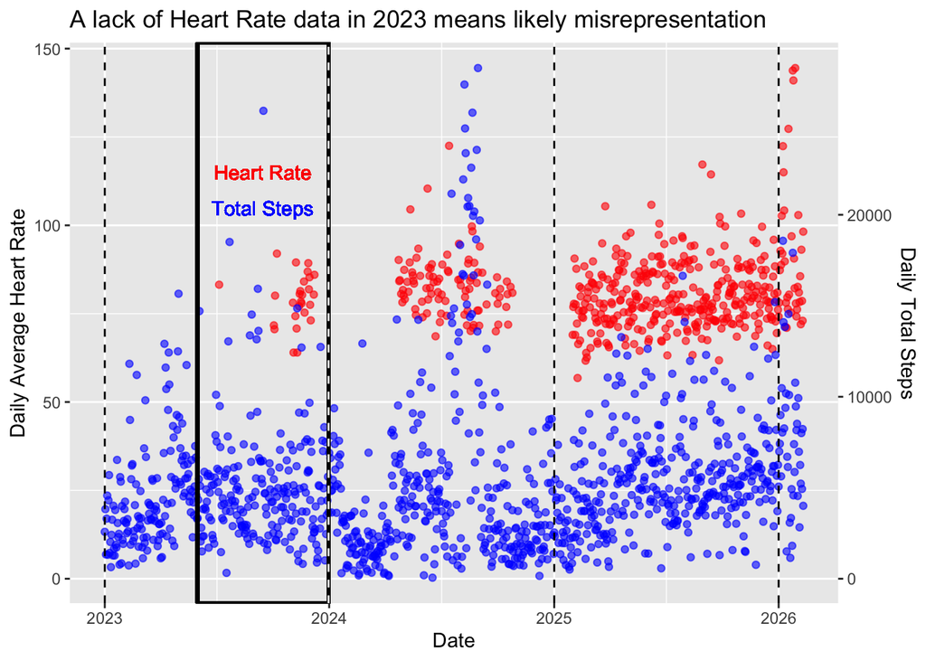

```r
# scaling factor
k <- max(health$Steps, na.rm = TRUE) / max(health$HeartRate, na.rm = TRUE)

ggplot(health, aes(x = Date)) +
  geom_point(aes(y = HeartRate), color = "red", alpha = 0.6) +
  geom_point(aes(y = Steps / k), color = "blue", alpha = 0.6) +
  scale_y_continuous(
    name = "Daily Average Heart Rate",
    sec.axis = sec_axis(~ . * k, name = "Daily Total Steps")
  )+
  geom_rect(
    aes(
      xmin = as.Date("2023-06-1"),
      xmax = as.Date("2023-12-31"),
      ymin = -Inf,
      ymax = Inf
    ),
    inherit.aes = FALSE,
    fill = NA,
    color = "black",
    linewidth = 1
  )+
  geom_text(
    aes(x = 19615, y = 115),
    label = "Heart Rate",
    color = "red"
  )+
  geom_text(
    aes(x = 19615, y = 105),
    label = "Total Steps",
    color = "blue"
  )+
  geom_vline(xintercept = c(19358,20089,20454), linetype = "dashed", color = "black")+
  geom_vline(xintercept = 19722, linetype = "dashed", color = "white")+
  labs(
    title = "A lack of Heart Rate data in 2023 means likely misrepresentation"
  )
```

- *Pvalue* - There is statistically significant evidence, at the 5% level (pvalue = 0.0103 with $\alpha = 0.05$), that baseline daily steps in 2023 differ from those in 2024–2026 when holding heart rate constant. This supports the conclusion that overall activity levels in 2023 were meaningfully different from later years.

**HeartRate × is_2023**

- *Estimate* - This interaction term indicates that the slope relating heart rate to steps is smaller in 2023 than in 2024–2026. Specifically, for 2023, the effect of heart rate on steps is reduced by about 279 steps per BPM relative to the baseline slope. Combining this with the main effect of heart rate implies that in 2023, higher heart rates are associated with a much weaker—and potentially negative—relationship with steps compared to other years.
- *Pvalue* - There is statistically significant evidence (pvalue = 0.009783 with $\alpha = 0.05$) that the relationship between heart rate and steps in 2023 differs from the relationship observed in 2024–2026. This confirms that the slope of the heart rate–steps association changed in 2023, consistent with the distinct pattern observed in the visualizations.

## Diagnostic Plots

**Residuals vs Fitted**

**Q–Q Residuals**

The Q–Q plot reveals a substantial departure from normality, particularly in the upper tail. While residuals near the center follow the theoretical normal line reasonably well, extreme positive residuals deviate sharply upward. This indicates a heavy right tail in the error distribution, driven by days with unusually high step counts. As a result, the normality assumption required for standard hypothesis testing is violated.

**Residuals vs Index**

The residuals plotted against observation index show no strong systematic pattern over time, suggesting that residuals are largely independent with respect to observation order. However, clusters of large residuals and several extreme values appear, reinforcing the presence of outliers and non-constant variance across observations.

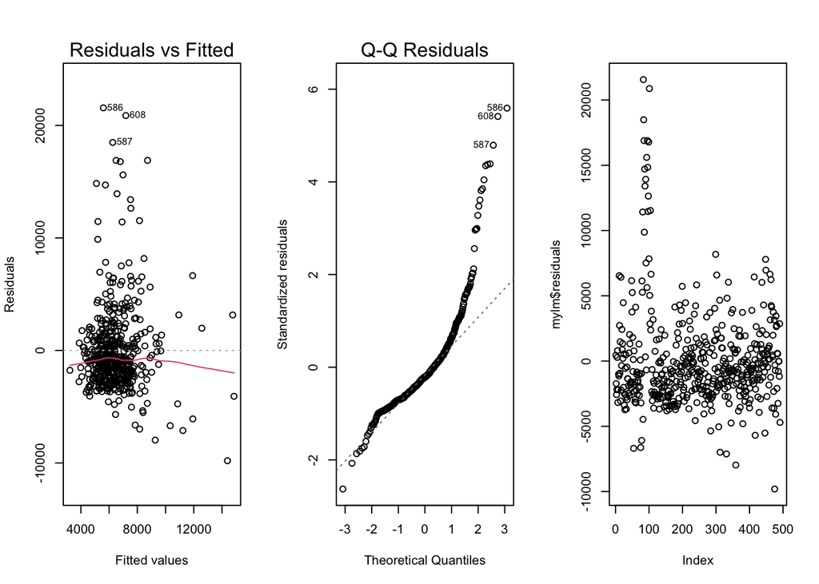

```r
# > Plots 1-3
par(mfrow=c(1,3))
plot(mylm,which=1:2)
plot(mylm$residuals)
```

**Cook’s distance**

This final diagnostic plot shows us none of the data are are meaningfully impactful on the slope of the line when popped out of the data. This relieves us of any reasonable concern that any one data point is responsible for the upward or downward slope of lines ploted several graphics above.

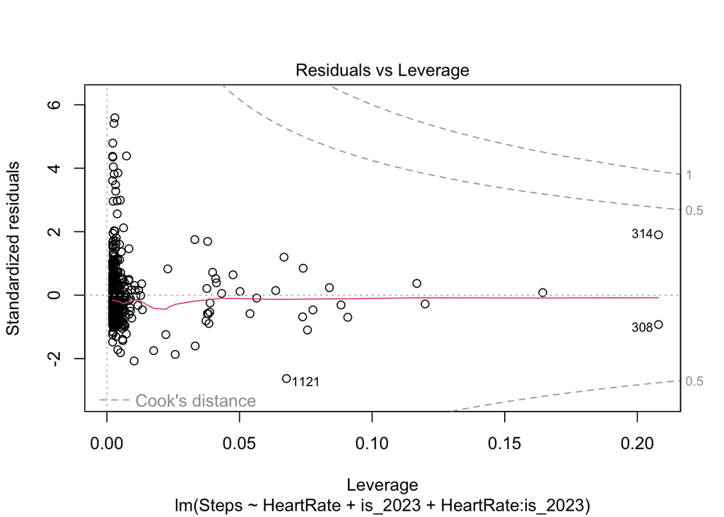

```r
# > Diagnostic Plot 5 (Cooks Distance)
plot(mylm, which = 5)
```

## Overall Assessment

While the linear regression model appears to capture the general relationship between heart rate and steps, **key assumptions**—particularly constant variance and normality of errors—are **violated**. These issues suggest that inference based on this model should be interpreted with caution, and that transformations of the response variable, robust standard errors, or alternative modeling approaches may be more appropriate.

> Footnotes
[^1]: [iPhone](https://www.apple.com/iphone/)
[^2]: [Apple Watch](https://www.apple.com/watch/)
[^3]: [iOS Health App](https://www.apple.com/health/)
[^4]: [iPhone SE](https://support.apple.com/en-us/112005)
[^5]: [iPhone](https://support.apple.com/en-us/111943)
[^6]: [iPhone 12 Pro](https://support.apple.com/en-us/111875)
[^7]: [Apple Watch 1](https://support.apple.com/en-us/111985)
[^8]: [iPhone 16 Pro Max](https://support.apple.com/en-us/121032)
[^9]: [Apple Watch Series 10](https://support.apple.com/en-us/121202)